# jekyll-jupyter-notebook20261006-3326-ks5p8d

## Predicting fraudulent credit card transactions

This project builds a model that can predict whether a credit card transaction is fraudulent or not. For this binary classification tast, I used XGBoost as it is fast, efficient and work well for imbalance data which is the case here.

```python
#importing the libraries

import pandas as pd
import numpy as np
import seaborn as sns
import matplotlib.pyplot as plt
import plotly.express as px

import gc
from datetime import datetime
from sklearn.model_selection import train_test_split
from sklearn.model_selection import KFold
from sklearn.metrics import roc_auc_score, roc_curve
from sklearn.metrics import classification_report, confusion_matrix
from sklearn.ensemble import RandomForestClassifier
from sklearn.ensemble import AdaBoostClassifier
#from catboost import CatBoostClassifier
from sklearn import svm
import lightgbm as lgb
from lightgbm import LGBMClassifier
import xgboost as xgb
from sklearn.model_selection import StratifiedKFold
```

### Reading the Data

```python
df = pd.read_csv('credit_card_fraud_10k.csv')
```

```python
#df.head()
```

```python
df.shape
```

```
(10000, 10)
```

```python
df.columns
```

```
Index(['transaction_id', 'amount', 'transaction_hour', 'merchant_category',
       'foreign_transaction', 'location_mismatch', 'device_trust_score',
       'velocity_last_24h', 'cardholder_age', 'is_fraud'],
      dtype='object')
```

```python
df.describe()
```

|  | transaction_id | amount | transaction_hour | foreign_transaction | location_mismatch | device_trust_score | velocity_last_24h | cardholder_age | is_fraud |
| --- | --- | --- | --- | --- | --- | --- | --- | --- | --- |
| count | 10000.00000 | 10000.000000 | 10000.000000 | 10000.000000 | 10000.000000 | 10000.000000 | 10000.000000 | 10000.000000 | 10000.000000 |
| mean | 5000.50000 | 175.949849 | 11.593300 | 0.097800 | 0.085700 | 61.798900 | 2.008900 | 43.468700 | 0.015100 |
| std | 2886.89568 | 175.392827 | 6.922708 | 0.297059 | 0.279935 | 21.487053 | 1.432559 | 14.979147 | 0.121957 |
| min | 1.00000 | 0.000000 | 0.000000 | 0.000000 | 0.000000 | 25.000000 | 0.000000 | 18.000000 | 0.000000 |
| 25% | 2500.75000 | 50.905000 | 6.000000 | 0.000000 | 0.000000 | 43.000000 | 1.000000 | 30.000000 | 0.000000 |
| 50% | 5000.50000 | 122.095000 | 12.000000 | 0.000000 | 0.000000 | 62.000000 | 2.000000 | 44.000000 | 0.000000 |
| 75% | 7500.25000 | 242.480000 | 18.000000 | 0.000000 | 0.000000 | 80.000000 | 3.000000 | 56.000000 | 0.000000 |
| max | 10000.00000 | 1471.040000 | 23.000000 | 1.000000 | 1.000000 | 99.000000 | 9.000000 | 69.000000 | 1.000000 |

### checking for missing data

```python
df.isnull().sum()
```

```
transaction_id         0
amount                 0
transaction_hour       0
merchant_category      0
foreign_transaction    0
location_mismatch      0
device_trust_score     0
velocity_last_24h      0
cardholder_age         0
is_fraud               0
dtype: int64
```

data is complete. no missing values

Finding the percentage of fraud and non-fraud cases

```python
non_fraud = len(df.query('is_fraud == 0'))
fraud = len(df.query('is_fraud == 1'))

non_fraud_percentage = non_fraud /(non_fraud +fraud)
print(non_fraud_percentage*100)

fraud_percentage = fraud/(non_fraud+fraud)
print(fraud_percentage*100)
```

```
98.49
1.51
```

### plotting the class distribution (fraudulent or not) in the data set

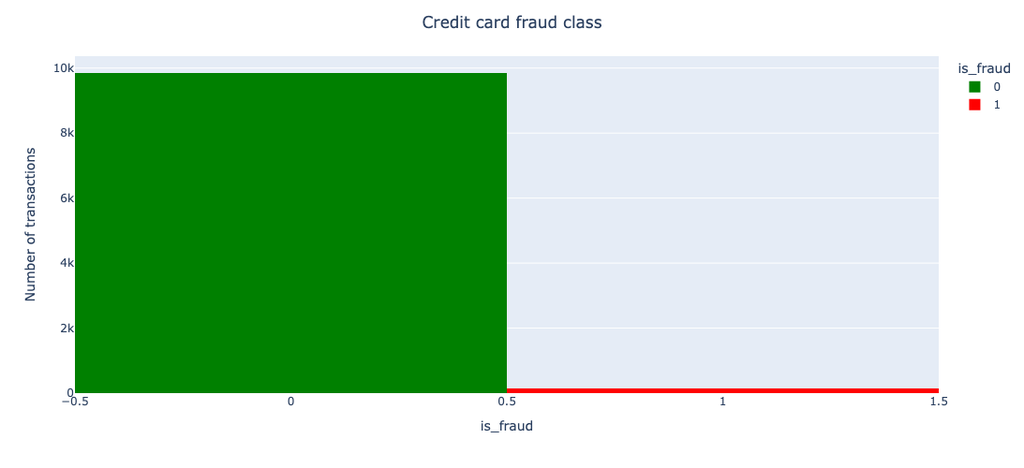

```python
fig = px.histogram(df, x='is_fraud',color='is_fraud',height=500, width=700,color_discrete_map={0: 'green',1: 'red'})
fig.update_layout(yaxis_title='Number of transactions', title={'text':'Credit card fraud class', 'x':0.5})
fig.show()
```

### checking to see if there are patterns in the fraudulent transactions and non-fradulent transactions over time

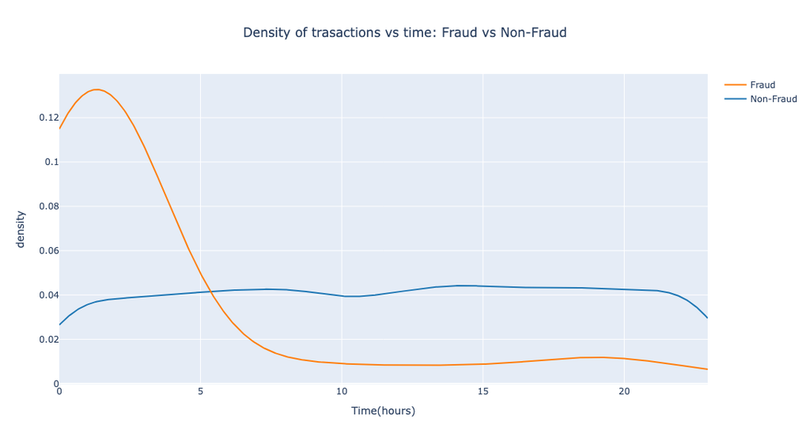

```python
import plotly.figure_factory as ff

class_0 = df[df["is_fraud"] == 0]["transaction_hour"]
class_1 = df[df["is_fraud"] == 1]["transaction_hour"]

fig = ff.create_distplot([class_0, class_1],
    group_labels=["Non-Fraud", "Fraud"],
    show_hist=False,
    show_rug=False
)

fig.update_layout(
    width=800,
    height=600,
    title="Density of trasactions vs time: Fraud vs Non-Fraud", title_x = 0.5,
    xaxis_title='Time(hours)',
    yaxis_title='density'
)

fig.show()
```

The fradulent activities show a pattern where more transctions are taking place during the early hours. Non-fradulent transactions are evenly distributed across the hours.

Looking into more details of the transactions between the two classes (fraudulent and non-fraudulent). We will look into the sum of transaction count, amount per hour.

We want to compute the statistics of transaction amounts for every hour and fraud class combination.

This will give us insight into things like:

1. Are fraudulent activities concentrated at a particular hour?
2. Are there more fraudulent activities later at night?
3. Do fraud amounts vary from normal transction amounts?

```python
df['transaction_hour'] = np.floor(df['transaction_hour'])
df_stat = df.groupby(['transaction_hour', 'is_fraud'])['amount'].aggregate(['min', 'max', 'count', 'sum', 'mean', 'median', 'var']).reset_index()

df_stat.head()
```

|  | transaction_hour | is_fraud | min | max | count | sum | mean | median | var |
| --- | --- | --- | --- | --- | --- | --- | --- | --- | --- |
| 0 | 0 | 0 | 0.79 | 1321.02 | 380 | 70342.49 | 185.111816 | 130.910 | 31803.351719 |
| 1 | 0 | 1 | 1.82 | 1185.07 | 37 | 7250.67 | 195.964054 | 91.310 | 78491.714075 |
| 2 | 1 | 0 | 0.16 | 1390.24 | 391 | 68814.72 | 175.996726 | 123.420 | 35394.694473 |
| 3 | 1 | 1 | 0.11 | 1103.19 | 34 | 8795.05 | 258.677941 | 110.305 | 90746.107950 |
| 4 | 2 | 0 | 0.14 | 973.32 | 362 | 63601.37 | 175.694392 | 125.335 | 26388.250183 |

### Plotting total number of transactions every hours

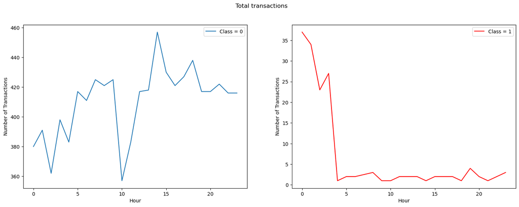

```python
fig, (ax1, ax2) = plt.subplots(ncols=2, figsize=(18,6))
s = sns.lineplot(ax = ax1, x="transaction_hour", y="count", data=df_stat.loc[df_stat.is_fraud==0], label='Class = 0')
s = sns.lineplot(ax = ax2, x="transaction_hour", y="count", data=df_stat.loc[df_stat.is_fraud==1], color="red", label='Class = 1')
ax1.set_xlabel("Hour")
ax2.set_xlabel("Hour")
ax1.set_ylabel("Number of Transactions")
ax2.set_ylabel("Number of Transactions")
plt.suptitle("Total transactions")
plt.legend()
plt.savefig('tot_transactions.png')
plt.show()
```

**For the fradulent case, more transactions are conglemerated in the early hours.**

### plotting the total amount for each transaction for every hour.

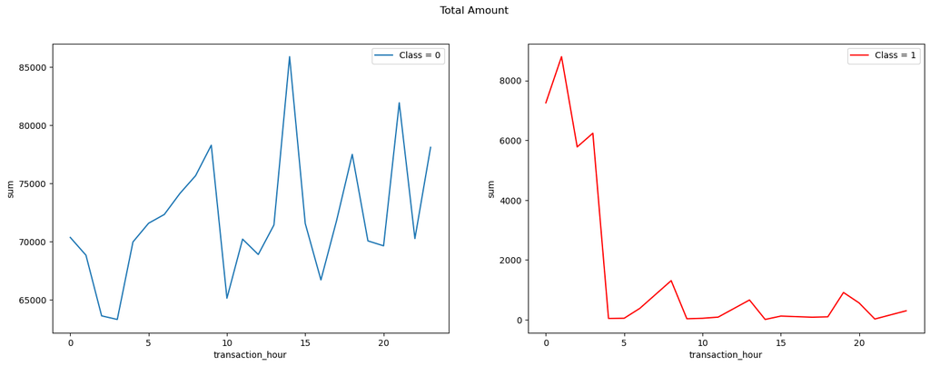

```python
fig, (ax1, ax2) = plt.subplots(ncols=2, figsize=(18,6))
s = sns.lineplot(ax = ax1, x="transaction_hour", y="sum", data=df_stat.loc[df_stat.is_fraud==0], label='Class = 0')
s = sns.lineplot(ax = ax2, x="transaction_hour", y="sum", data=df_stat.loc[df_stat.is_fraud==1], color="red", label='Class = 1')
plt.suptitle("Total Amount")
plt.savefig('tot_amount.png')
plt.show()
```

For the fraudulent case, the summed amount for every hour is much less compared to the non fraudulent case. Highest variation is seen huring the early hours.

For the non-fradulent case, the summed amounts are very high and there's no clear pattern seen.

### Looking at categorical features

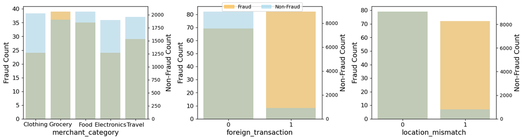

```python
categorical_features = ['merchant_category','foreign_transaction','location_mismatch']

fig, ax = plt.subplots(1, 3, figsize=(15,4))

for i, col in enumerate(categorical_features):

    sns.countplot(
        x=df.query('is_fraud == 1')[col],
        ax=ax[i],
        alpha=0.5,
        color='orange'
    )

    ax[i].set_ylabel("Fraud Count", fontsize=14)
    ax[i].set_xlabel(col, fontsize=14)
    ax[i].tick_params(axis='x', labelsize=12)
    ax[i].tick_params(axis='y', labelsize=12)

    ax2 = ax[i].twinx()

    sns.countplot(
        x=df[df['is_fraud'] == 0][col],
        ax=ax2,
        alpha=0.5,
        color='skyblue'
    )

    ax2.set_ylabel("Non-Fraud Count", fontsize=14)

# Create one shared legend
handles = [
    plt.Rectangle((0,0),1,1,color='orange',alpha=0.5),
    plt.Rectangle((0,0),1,1,color='skyblue',alpha=0.5)
]

labels = ['Fraud', 'Non-Fraud']

fig.legend(handles, labels, loc='upper center', ncol=2)

plt.tight_layout()
plt.savefig('categorical_features.png')
plt.show()
```

The merchant category is doesn't show a significant mismatch between fradulent and non-fraudulent transactions.

### Density Plots for the features

Creating density plots for the features. These plots show how the values for each feature is distributed and it clearly show the differences in the distribution for the two classes, Class 0 and Class 1.

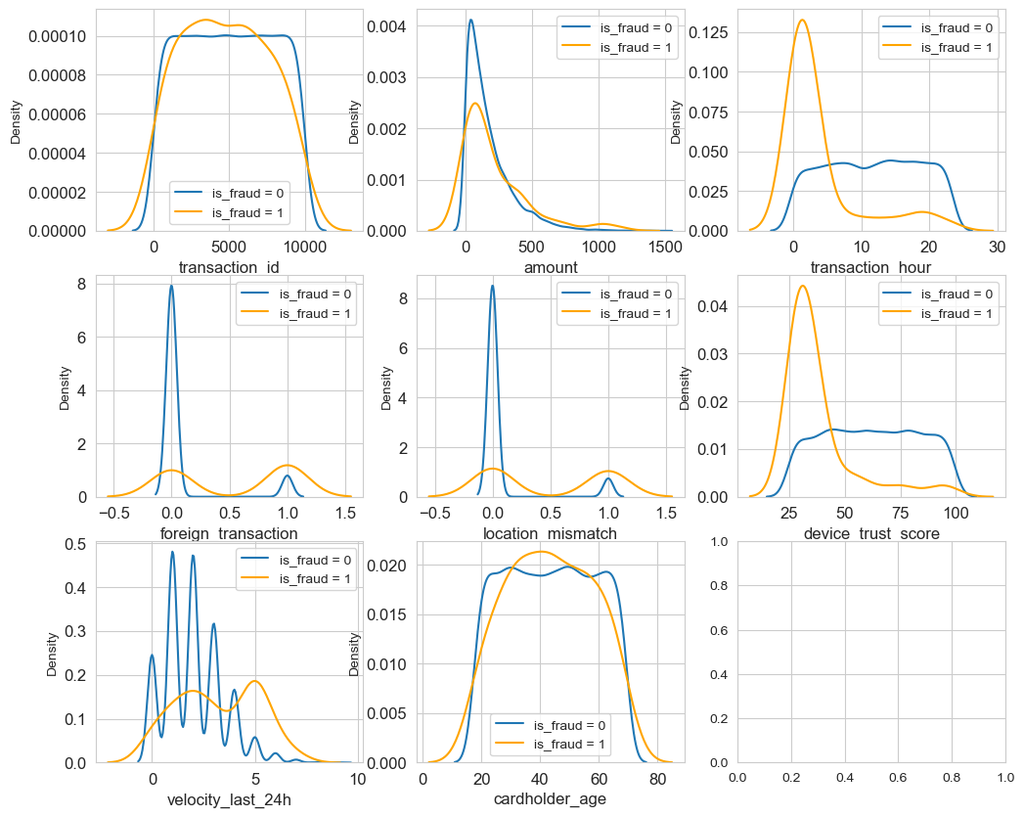

```python
var = df.drop(['is_fraud', 'merchant_category'], axis=1).columns

i = 0
t0 = df.loc[df['is_fraud'] == 0]   # selecting the dataframe where Class = 0
t0 = t0.drop(['is_fraud'], axis=1) # dropping the Class column
t1 = df.loc[df['is_fraud'] == 1]   # selecting the dataframe where Class = 1
t1 = t1.drop(['is_fraud'], axis=1)

sns.set_style('whitegrid')
plt.figure()
fig, ax = plt.subplots(3,3,figsize=(12,10))

for f in var:
    i += 1
    plt.subplot(3,3,i)
    sns.kdeplot(t0[f],label="is_fraud = 0")
    sns.kdeplot(t1[f],label="is_fraud = 1", color='orange')
    plt.xlabel(f, fontsize=12)
    locs, labels = plt.xticks()
    plt.tick_params(axis='both', which='major', labelsize=12)
    plt.legend()

plt.savefig('feature_density_plots.png')
plt.show()
```

### Predictive Model

Creating a predictive models that can classify if a certain transaction is fraudulent or not

```python
target = 'is_fraud'
predictors = ['transaction_id', 'amount', 'transaction_hour',
       'foreign_transaction', 'location_mismatch', 'device_trust_score',
       'velocity_last_24h', 'cardholder_age']
```

#### splitting the data into train, test and validation set

```python
VALID_SIZE = 0.20 # simple validation using train_test_split
TEST_SIZE = 0.20 # test size using_train_test_split
RANDOM_STATE = 20

train_df, test_df = train_test_split(df, test_size=TEST_SIZE, random_state=RANDOM_STATE, shuffle=True )
train_df, valid_df = train_test_split(df, test_size=VALID_SIZE, random_state=RANDOM_STATE, shuffle=True )
```

### XGBoost

```python
# Prepare the train and valid datasets.
# creating a special data structure used by XGBoost for faster and memory efficient training
dtrain = xgb.DMatrix(train_df[predictors], train_df[target].values)
dvalid = xgb.DMatrix(valid_df[predictors], valid_df[target].values)
dtest = xgb.DMatrix(test_df[predictors], test_df[target].values)

#What to monitor (in this case, **train** and **valid**)
watchlist = [(dtrain, 'train'), (dvalid, 'valid')]   # will evaluate the performance ob both datasets after every boosting round
```

```python
# Set xgboost parameters
params = {}
params['objective'] = 'binary:logistic'
params['eta'] = 0.039                   # control how much each tree contributes to the final prediction
params['verbosity'] = 0                 # Suppresses training messages/output
params['max_depth'] = 2                 # controls tree complexity. Small depth:simpler trees, less overfitting, more bias
                                        # Large depth:complex trees, captures complicated patterns, higher overfitting risk
params['subsample'] = 0.8               # randomly samples 80% of training rows for each tree. Purpose:reduce overfitting,increase randomness, improve generalization
params['colsample_bytree'] = 0.9        # Each tree only sees 90% of features.purpose: reduce correlation between trees
params['eval_metric'] = 'auc'           # model performance parameter. ROC-AUC score here
params['random_state'] = RANDOM_STATE
```

#### Training the model

```python
MAX_ROUNDS = 1000 #number of iterations
EARLY_STOP = 50   #early stop
OPT_ROUNDS = 1000  #To be adjusted based on best validation rounds
VERBOSE_EVAL = 50 #Print out metric result

evals_results = {}
model_xgb = xgb.train(params,
                dtrain,
                MAX_ROUNDS,                           # This is the maximum number of boosting iterations (trees).
                evals=watchlist,
                early_stopping_rounds=EARLY_STOP,     # EARLY_STOP = 50. if validation AUC doesnt improve for 50 rounds, training stops
                maximize=True,                        # since we are using the auc metric. we need to maximize it.
                verbose_eval=VERBOSE_EVAL,            # Controls how often training progress is printed. Since VERBOSE_EVAL = 50, every 50 rounds
                evals_result=evals_results,
                )
```

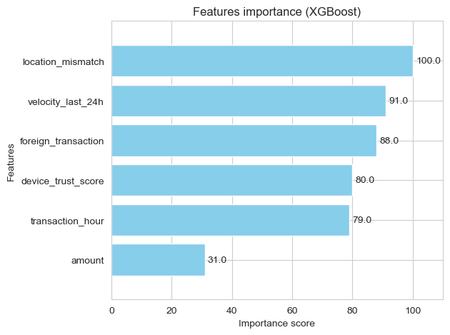

```python
plt.figure(figsize=(8,6))
xgb.plot_importance(model_xgb, height=0.8, title="Features importance (XGBoost)", color="skyblue")
plt.tight_layout()
plt.savefig('feature_importance.pdf')
plt.show()
```

#### predict using the model

```python
test_preds = model_xgb.predict(dtest)
```

#### confusion matrix

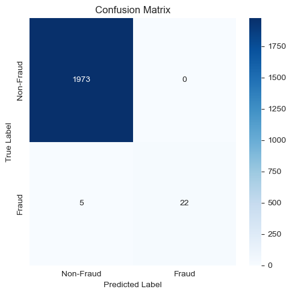

```python
# convert probabilities to 0 and 1 classes
test_preds_classes = (test_preds > 0.5).astype(int)

cm_xg = confusion_matrix(test_df[target], test_preds_classes)

# Labels for display
labels = ["Non-Fraud", "Fraud"]

# Plot the confusion matrix
plt.figure(figsize=(5, 5))
sns.heatmap(cm_xg, annot=True, fmt='d', cmap='Blues',
            xticklabels=labels, yticklabels=labels)
plt.title("Confusion Matrix")
plt.xlabel("Predicted Label")
plt.ylabel("True Label")
plt.tight_layout()
plt.savefig('confusion_matrix.png')
plt.show()
```

The model accurately predicted 1973 cases as non-fraudulent. 5 cases were wrongly labeled as non-fraud. Model accurately predicted 22 cases as fraudulent

Due to the data imbalance between fraudulent and non-fraudulent cases, using the ROC-AUC (Area Under the Receiver Operating Characteristic Curve) metric to measure the accuracy makes more sense:

```python
test_auc = roc_auc_score(test_df[target].values, test_preds)
test_auc
```

```
0.9999812280602954
```

#### The AUC score for XGBoost is 0.999.

#### Plotting one decision tree used as one stage of the gradient boosting ensemble.

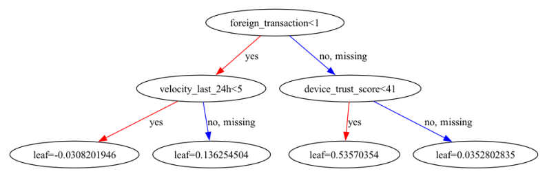

```python
fig, ax = plt.subplots(figsize=(10, 8))

xgb.plot_tree(model_xgb,tree_idx=0,ax=ax)
plt.show()
```

#### Plotting learning curves

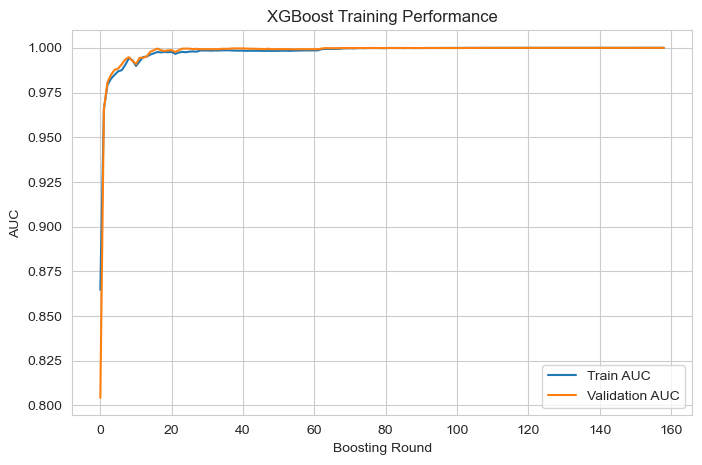

```python
train_auc = evals_results['train']['auc']
valid_auc = evals_results['valid']['auc']

plt.figure(figsize=(8,5))

plt.plot(train_auc, label='Train AUC')
plt.plot(valid_auc, label='Validation AUC')

plt.xlabel("Boosting Round")
plt.ylabel("AUC")
plt.title("XGBoost Training Performance")
plt.legend()
plt.savefig('learning_curve.png')
plt.show()
```

### calculating the cross validation score.

This is more reliable than using a single test split and calculating its AUC.

```python
from xgboost import XGBClassifier

NUMBER_KFOLDS = 5
kf = KFold(n_splits = NUMBER_KFOLDS, random_state = RANDOM_STATE, shuffle = True)

# Create arrays and dataframes to store results
oof_preds = np.zeros(train_df.shape[0])
test_preds = np.zeros(test_df.shape[0])
feature_importance_df = pd.DataFrame()
n_fold = 0

for train_idx, valid_idx in kf.split(train_df[predictors], train_df[target]):
    train_x, train_y = train_df[predictors].iloc[train_idx],train_df[target].iloc[train_idx]
    valid_x, valid_y = train_df[predictors].iloc[valid_idx],train_df[target].iloc[valid_idx]

    evals_results = {}
    model =  XGBClassifier(
                  #nthread=-1,
                  n_estimators=2000,
                  learning_rate=0.01,
                  max_depath =4,
                  colsample_bytree=0.98,
                  subsample=0.78,
                  reg_alpha=0.04,
                  reg_lambda=0.073,
                  eval_metric='auc',
                  silent=-1,
                  verbose=-1,
                  early_stopping_rounds=50,
                  feval=None)

    model.fit(
        train_x,
        train_y,
        eval_set=[(valid_x, valid_y),(valid_x, valid_y) ],
        verbose=50
        )
    oof_preds[valid_idx] = model.predict_proba(valid_x)[:, 1] #takes probability for all the rows where class=1 in valid_x. if a row doesn't have class=1, probability for that case will be 0.
    test_preds += model.predict_proba(test_df[predictors])[:, 1] / kf.n_splits
    # each fold adds its contribution to test_preds and then we take the average by diving the value by kf.n_splits(=5)
    fold_importance_df = pd.DataFrame()
    fold_importance_df["feature"] = predictors
    fold_importance_df["importance"] = model.feature_importances_
    fold_importance_df["fold"] = n_fold + 1

    feature_importance_df = pd.concat([feature_importance_df, fold_importance_df], axis=0)
    print('Fold %2d AUC : %.6f' % (n_fold + 1, roc_auc_score(valid_y, oof_preds[valid_idx])))
    del model, train_x, train_y, valid_x, valid_y
    gc.collect()
    n_fold = n_fold + 1
oof_auc_score = roc_auc_score(train_df[target], oof_preds)
print('Overall AUC score %.6f' % oof_auc_score)
```

```
Fold  1 AUC : 1.000000
Fold  2 AUC : 0.999936
Fold  3 AUC : 1.000000
Fold  4 AUC : 0.999608
Fold  5 AUC : 1.000000
Overall AUC score 0.999871
```

### Cost Estimation

```python
test_preds = model_xgb.predict(dtest)
test_auc = roc_auc_score(test_df[target].values, test_preds)
test_auc
```

```
0.9999812280602954
```

```python
prob_success =  model_xgb.predict(dtest)   # probability of fraudulent transactions for the test dataset
prob_success
```

```
array([0.00198281, 0.00198281, 0.0040895 , ..., 0.00019953, 0.00112521,
       0.0002339 ], shape=(2000,), dtype=float32)
```

### adding a threshold

```python
threshold = 0.7
decision = (prob_success>=threshold).astype(int)
decision
```

```
array([0, 0, 0, ..., 0, 0, 0], shape=(2000,))
```

```python
amount_list = np.array(test_df[predictors]['amount'])
amount_list
```

```
array([254.43, 120.17, 104.47, ..., 382.63, 283.21, 341.45], shape=(2000,))
```

```python
savings = amount_list[decision == 1]
```

```python
print('estimated savings for 2000 transactions: %0.2f'%(np.sum(savings)))
```

```
estimated savings for 2000 transactions: 390.92
```

```python
daily_savings =  (390.92/2000)*10000
daily_savings
```

```
1954.6
```

```python
fraud_prevented_per_month = daily_savings*30
print('Total fraud prevented per month: %0.2f'%(fraud_prevented_per_month))
```

```
Total fraud prevented per month: 58638.00
```